# R u Ready? HS2025 | Psychologie der Digitalisierung - Einheit 7

Sandra Grinschgl, Aaron Friedli, Lars Schilling

## R u Ready? Reproduzierbare Datenaufbereitung und -analyse mit R

HS 2025  
**LV-Leitung**: Dr. Sandra Grinschgl / MSc. Aaron Friedli  
**Tutor**: BSc. Lars Schilling  
**7. Einheit**, 29.10.2025

## Heute:

[interactive chart not shown]

## Fragen zu Hands On Block 2?

[figure not shown]

## Pipe:

- Aus dem *magrittr*-Package %>% (Teil des *tidyverse*) oder Base R |>
- Zweck: Macht Code leserlicher und verständlicher
- Hilft bei Funktionen, die als erstes Argument Daten erwarten

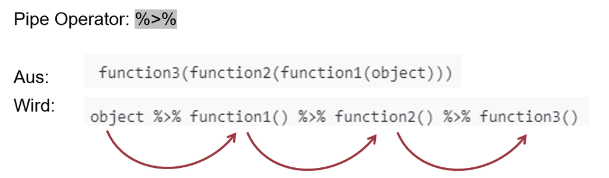

## Pipe: Beispiel

👎Unübersichtliche verschachtelte Funktion

```r
library(palmerpenguins)
library(tidyverse)

head(select(filter(penguins, species == "Adelie"), species, bill_length_mm))
```

👍 Übersichtlich und nachvollziehbar mit der Pipe

```r
penguins |>
  filter(species == "Adelie") |>
  select(species, bill_length_mm) |>
  head()
```

```
# A tibble: 6 × 2
  species bill_length_mm
  <fct>            <dbl>
1 Adelie            39.1
2 Adelie            39.5
3 Adelie            40.3
4 Adelie            NA
5 Adelie            36.7
6 Adelie            39.3
```

## Tidyverse: dplyr

*Bietet und einige der wichtigsten Funktionen für die Datenaufbereitung!*

[figure not shown]

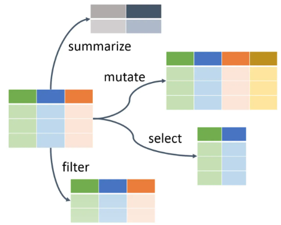

## dplyr: filter()

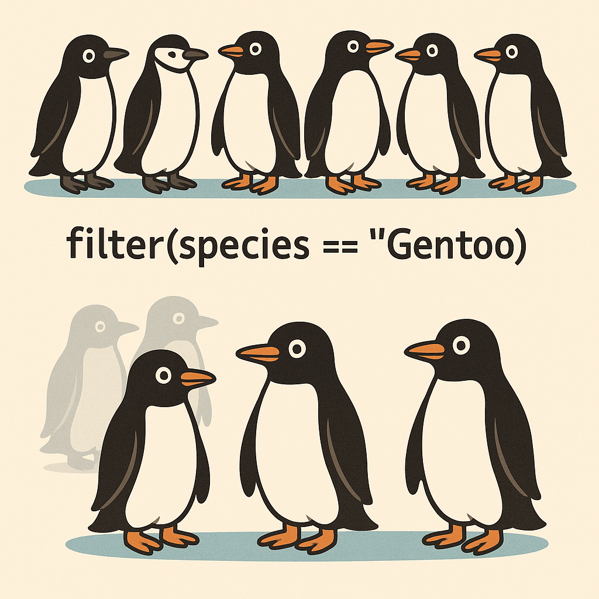

## dplyr: filter()

**Filtert den Datensatz basierend auf den logischen Argumenten die wir geben.**

- **Rows (Zeilen) auswählen**

```r
library(palmerpenguins)

penguins |>
  filter(species == "Gentoo")
```

```
# A tibble: 124 × 8
   species island bill_length_mm bill_depth_mm flipper_length_mm body_mass_g
   <fct>   <fct>           <dbl>         <dbl>             <int>       <int>
 1 Gentoo  Biscoe           46.1          13.2               211        4500
 2 Gentoo  Biscoe           50            16.3               230        5700
 3 Gentoo  Biscoe           48.7          14.1               210        4450
 4 Gentoo  Biscoe           50            15.2               218        5700
 5 Gentoo  Biscoe           47.6          14.5               215        5400
 6 Gentoo  Biscoe           46.5          13.5               210        4550
 7 Gentoo  Biscoe           45.4          14.6               211        4800
 8 Gentoo  Biscoe           46.7          15.3               219        5200
 9 Gentoo  Biscoe           43.3          13.4               209        4400
10 Gentoo  Biscoe           46.8          15.4               215        5150
# ℹ 114 more rows
# ℹ 2 more variables: sex <fct>, year <int>
```

## dplyr: select()

- **Colums (Spalten) auswählen**

```
# A tibble: 344 × 3
   species island    bill_length_mm
   <fct>   <fct>              <dbl>
 1 Adelie  Torgersen           39.1
 2 Adelie  Torgersen           39.5
 3 Adelie  Torgersen           40.3
 4 Adelie  Torgersen           NA
 5 Adelie  Torgersen           36.7
 6 Adelie  Torgersen           39.3
 7 Adelie  Torgersen           38.9
 8 Adelie  Torgersen           39.2
 9 Adelie  Torgersen           34.1
10 Adelie  Torgersen           42
# ℹ 334 more rows
```

## dplyer: select ()

[figure not shown]

## dplyr: select()

- **Mit Hilfsfunktionen wie** `starts_with`

```r
penguins |>
  select(starts_with("bill"))
```

```
# A tibble: 344 × 2
   bill_length_mm bill_depth_mm
            <dbl>         <dbl>
 1           39.1          18.7
 2           39.5          17.4
 3           40.3          18
 4           NA            NA
 5           36.7          19.3
 6           39.3          20.6
 7           38.9          17.8
 8           39.2          19.6
 9           34.1          18.1
10           42            20.2
# ℹ 334 more rows
```

## dplyr: select()

- **Ausschliessen mit `-`**

```r
penguins |>
  select(-species, -island)
```

```
# A tibble: 344 × 6
   bill_length_mm bill_depth_mm flipper_length_mm body_mass_g sex     year
            <dbl>         <dbl>             <int>       <int> <fct>  <int>
 1           39.1          18.7               181        3750 male    2007
 2           39.5          17.4               186        3800 female  2007
 3           40.3          18                 195        3250 female  2007
 4           NA            NA                  NA          NA <NA>    2007
 5           36.7          19.3               193        3450 female  2007
 6           39.3          20.6               190        3650 male    2007
 7           38.9          17.8               181        3625 female  2007
 8           39.2          19.6               195        4675 male    2007
 9           34.1          18.1               193        3475 <NA>    2007
10           42            20.2               190        4250 <NA>    2007
# ℹ 334 more rows
```

## dplyr: summarize()

- **Fasst Daten zusammen**, indem Kennwerte (z. B. Mittelwerte) berechnet werden.
- **Reduziert** viele Zeilen zu einer oder wenigen zusammengefassten Zeilen.
- Wird oft mit `group_by()` kombiniert, um Kennwerte pro Gruppe zu berechnen.

```r
penguins |>
  summarise(
    mean_bill_length = mean(bill_length_mm, na.rm = TRUE),
    mean_flipper_length = mean(flipper_length_mm, na.rm = TRUE)
  )
```

```
# A tibble: 1 × 2
  mean_bill_length mean_flipper_length
             <dbl>               <dbl>
1             43.9                201.
```

## dplyr: summarize()

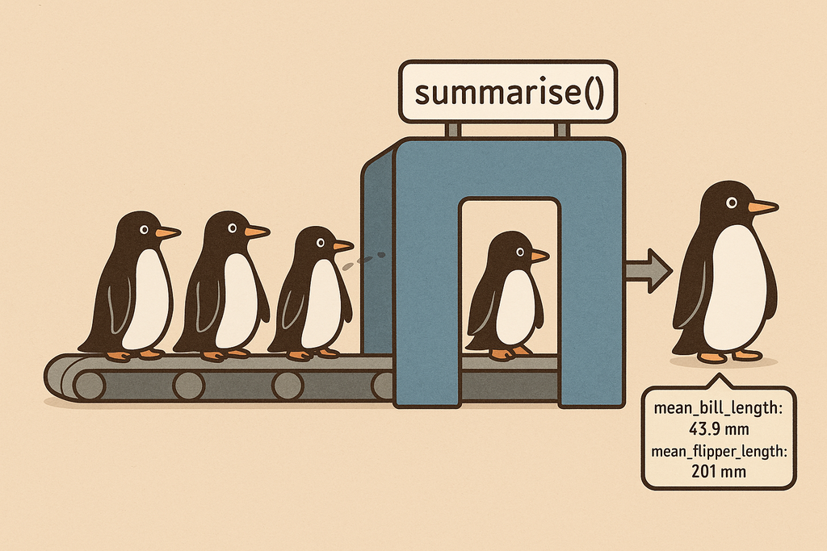

## dplyr: mutate()

- **Erstellt neue Variablen** oder verändert Bestehende.
- **Behält alle Zeilen** des ursprünglichen Datensatzes bei.
- Wird oft genutzt, um **berechnete Spalten** hinzuzufügen (z. B. `bill_to_flipper_ratio`).

```r
library(tidyverse)
library(palmerpenguins)

penguins_upgraded <- penguins |>
  mutate(
    bill_to_flipper_ratio = bill_length_mm / flipper_length_mm,
    body_mass_kg = body_mass_g / 1000
  )

head(penguins_upgraded)
```

```
# A tibble: 6 × 10
  species island    bill_length_mm bill_depth_mm flipper_length_mm body_mass_g
  <fct>   <fct>              <dbl>         <dbl>             <int>       <int>
1 Adelie  Torgersen           39.1          18.7               181        3750
2 Adelie  Torgersen           39.5          17.4               186        3800
3 Adelie  Torgersen           40.3          18                 195        3250
4 Adelie  Torgersen           NA            NA                  NA          NA
5 Adelie  Torgersen           36.7          19.3               193        3450
6 Adelie  Torgersen           39.3          20.6               190        3650
# ℹ 4 more variables: sex <fct>, year <int>, bill_to_flipper_ratio <dbl>,
#   body_mass_kg <dbl>
```

## dplyr: mutate()

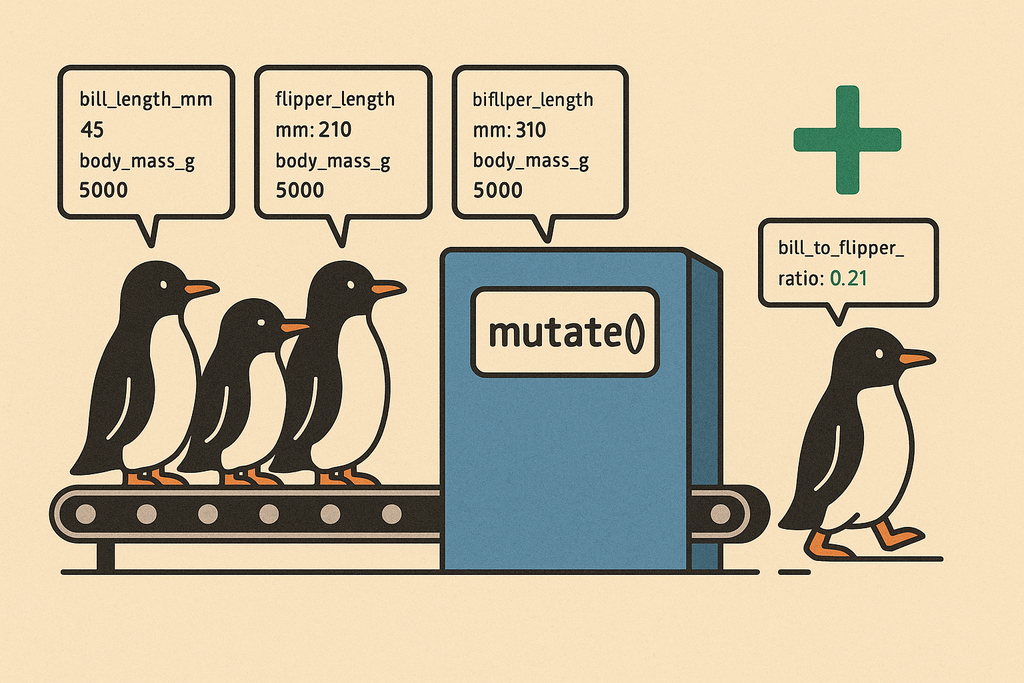

## dplyr: group_by()

- **Teilt den Datensatz in Gruppen** auf (z. B. nach `species`).
- **Verändert die Daten nicht**, sondern markiert sie intern als gruppiert.
- **Bereitet Daten auf Aggregationen** mit `summarise()` oder Berechnungen mit `mutate()` vor.

```r
grouped_summary <- penguins |>
  group_by(species) |>
  summarise(
    mean_bill_length = mean(bill_length_mm, na.rm = TRUE),
    mean_flipper_length = mean(flipper_length_mm, na.rm = TRUE)
  )

grouped_summary
```

```
# A tibble: 3 × 3
  species   mean_bill_length mean_flipper_length
  <fct>                <dbl>               <dbl>
1 Adelie                38.8                190.
2 Chinstrap             48.8                196.
3 Gentoo                47.5                217.
```

## dplyr: group_by()

[figure not shown]

## Heute haben wir:

- Die Pipe kennengelernt
- Dplyr Funktionen (Teil des tidyverse) zur Datenaufbereitung kennengelernt

## Hausübung

- Bis 7.11.2025 (Freitag nach EH 8)
- Alle Instruktionen auf der Website
- Danach Peer Feedback (Instruktionen folgen in EH 8)